# ESM 206 Assignment 4 - Spiny Lobsters in the Santa Barbara Channel

Alex Ehrens & Courtney Krone

11/11/2019

### 1. Introduction

The California spiny lobster (*Panulirus interruptus*) is an important species along the Southern California coast and plays a key role in maintaining diversity in kelp forests (National Park Service, 2016). These lobsters are a common target for fishermen, which greatly affects their size and abundance in the kelp forest ecosystems (National Park Service, 2016). This report explores the relationship between the abundance and size distribution of the California spiny lobster at 5 locations along the Santa Barbara channel. On January 1st, 2012, two of the 5 sites were designated as marine protected areas (MPAs) by the California Department of Fish and Wildlife (SBC LTER, 2019). Human activity, including fishing, is restricted in MPAs, and as a result many have shown positive trends of habitat recovery (Santa Barbara Channelkeeper). This report hopes to answer the question of whether MPAs affect the California spiny lobster size and abundance along the Santa Barbara coast. This will help assess the recovery of the kelp forest ecosystem.

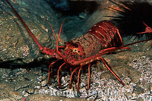

California Spiny Lobster. Long Point, Catalina, California. Photographer: Keoki Stender

### 2. Data and Methods

The two variables being analyzed in this report are lobster size (mm) and lobster abundance at 5 sites along the Santa Barbara channel between years 2012 and 2018. Data on abundance and size were collected annually by divers just before the start of the fishing season in late summer (SBC LTER, 2019). Lobster counts were compared at each site over the time period of 2012 to 2018. Welch’s two sample t-test and Cohen’s d effect size test were used to compare lobster sizes at MPA and non-MPA sites for 2012 and 2018. The following samples were compared:

- 2012 MPA vs. 2012 Non-MPA sites
- 2018 MPA vs. 2018 Non-MPA sites
- 2012 MPA vs. 2018 MPA sites
- 2012 Non-MPA vs. 2018 Non-MPA sites

A 95% confidence level was used to determine significance. Rstudio Version 1.2.1335 was used to analyze data, create figures and tables, and run statistical tests.

### 3. Results

#### a. Results A - Lobster Abundance

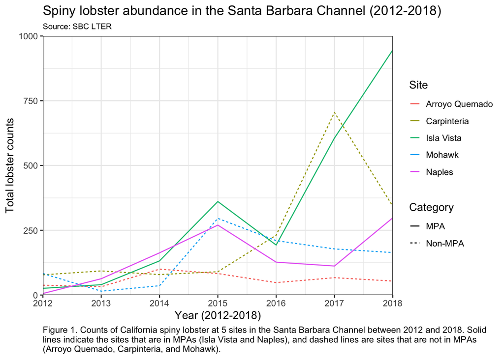

In general, the total lobster abundances at each of the 5 survey sites have increased from 2012 to 2018. However, the only two sites to show an increase in abundance over the final year of study (2017 to 2018) are Isla Vista and Naples, both of these sites are located in MPAs. The three sites that are not in MPAs show a decrease in total lobster abundance over the final year of the survey. It appears from the trends in Figure 1 that designated MPAs help improve lobster abundance in those areas.

#### b. Results B - Lobster Size Distribution

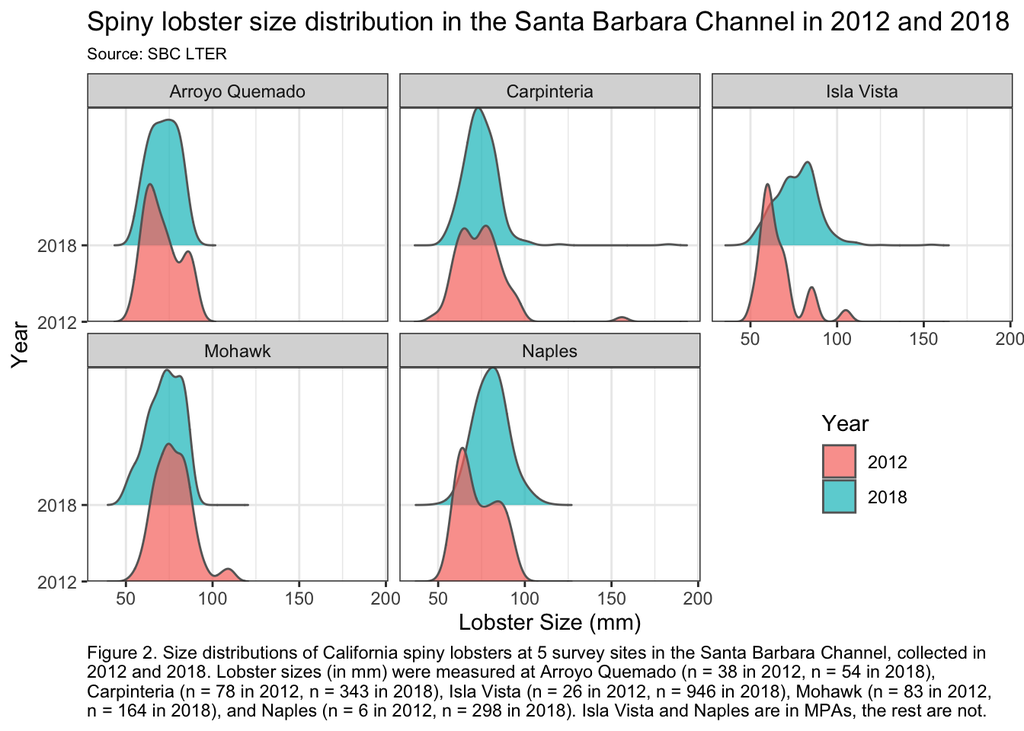

The density plots in Figure 2 show the distribution of lobster sizes (mm) at each site in 2012 and 2018. The two MPA sites, Isla Vista and Naples, show a positive shift in lobster size distribution in 2018 compared to 2012. However, the non-MPA sites, Arroyo Quemado, Mohawk and Carpinteria, show little to no shifts in lobster size distribution. Based on trends shown in Figure 2, lobster populations are able to grow larger at MPA sites which may indicate they are healthier and living longer due to reduced fishing and a flourishing habitat.

#### c. Results C - Mean Lobster Size Comparisons

Table 1. Summary statistics (mean, standard deviation, and number of counts) of California spiny lobster size distributions at MPA vs. non-MPA sites in 2012 and 2018

| Year | MPA or Non-MPA | Mean Size (mm) | Standard Deviation (mm) | Count |
| --- | --- | --- | --- | --- |
| 2012 | MPA | 67.38 | 12.15 | 32 |
| 2012 | Non-MPA | 74.92 | 12.41 | 199 |
| 2018 | MPA | 77.57 | 11.70 | 1244 |
| 2018 | Non-MPA | 73.62 | 10.09 | 561 |

Comparing the results for mean lobster sizes at MPA and non-MPA sites in 2012 and 2018 provides insight into the recovery of kelp forest ecosystems in the Santa Barbara Channel. The results of the statistical summary of lobster size samples are listed in Table 1. The most striking result is that the mean lobster size in MPA sites increased from 67.38 mm (n = 32) to 77.57 mm (n = 1244), an increase of 10.19 mm. These means were found to be significantly different (t = -4.69, p < 0.0001) with a large effect size (Cohen’s d = -0.87). The result is a significant increase in mean lobster size from 2012 to 2018, which suggests that MPA designation is contributing to improved lobster health and longevity.

In constrast, the samples collected in non-MPA sites in 2012 and 2018 did not show a significant difference in mean lobster size (t = 1.33, p = 0.18). The sample means actually decreased slightly from 74.92 mm (n = 199) to 73.62 mm (n = 561). The effect size (Cohen’s d = 0.12) was negligible, meaning that the sample means in 2012 and 2018 are very close to each other. The result is a lack of significant difference in mean lobster sizes in non-MPA sites between 2012 and 2018.

### 4. Summary

The results from the data analysis on California spiny lobsters in the Santa Barbara Channel suggest the following conclusions:

- Between 2012 and 2018, spiny lobster abundances have increased more at MPA sites than at non-MPA sites, as seen in Figure 1.
- The distributions of lobster sizes shown in Figure 2 have shifted positively (increased in size) from 2012 to 2018 only at the two MPA sites, whereas the non-MPA sites did not show any differences in size distribution between 2012 and 2018 samples.
- As seen in Table 1, there was a significant increase in mean lobster sizes at MPA sites from 2012 to 2018. No significant difference in mean lobster sizes could be determined at non-MPA sites from 2012 to 2018. MPA sites have gone from having smaller mean lobster sizes than non-MPA sites in 2012, to slightly larger mean lobster sizes than non-MPA sites in 2018.
- The results from this statistical analysis provide evidence that MPA designations have been effective in improving California spiny lobster health and abundance in the Santa Barbara Channel, which may suggest an improvement in kelp forest ecosystem health as well.

### 5. References

[1] Reed D. 2019. *SBC LTER: Reef: Abundance, size and fishing effort for California Spiny Lobster (Panulirus interruptus), ongoing since 2012.* Environmental Data Initiative. https://doi.org/10.6073/pasta/a593a675d644fdefb736750b291579a0

[2] “California Spiny Lobster.” National Parks Service, U.S. Department of the Interior, 13 July 2016. https://www.nps.gov/chis/learn/nature/california-spiny-lobster.htm

[3] “Learn about MPAs: Santa Barbara Channelkeeper: Keeping Watch for Clean Water.” Santa Barbara Channelkeeper. https://www.sbck.org/current-issues/marine-conservation/marine-protected-areas/learn-about-mpas/